# Coursera Practical Machine Learning : Course Project

Yusuke Yamamoto

19/06/2014

The objective of this analysis is to predict the manner in which six participants did the exercise. They performed the excercise in five different ways; one exactly follows the specification, and the other four follow the specification incorrect way.

### Pre-Processing

Before fitting a model, the training data are split into two parts; one for training the model, and the other for the cross validation. We take approximately 60% of the data as the training data, and 40% as the cross validation.

Some variables are highly correlated as the picture below.

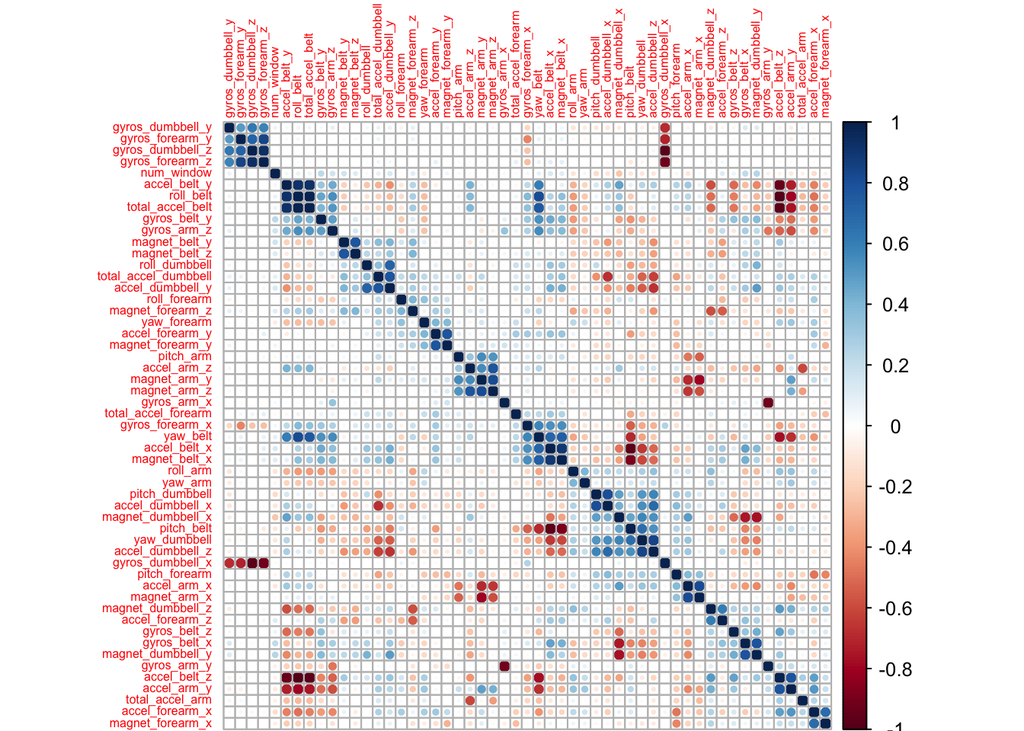

```r
cor.dat <- cor(subset(trainingall, select=-c(new_window, classe)))
corrplot(cor.dat, order="hclust", tl.cex=0.5)
```